# Benchmark rsofun tag v4.2

## Load rsofun

Get rsofun at tag v4.2 and install it.

```r
# devtools::install_github("computationales/rsofun@v4.2")
library(rsofun)
versionname <- "v4.2"
```

## Description

This is to run the same evaluation of GPP simulated by the P-model as done for [Stocker et al. (2020)](https://gmd.copernicus.org/articles/13/1545/2020/), using data from the FLUXNET2015 Tier 1 ensemble. Model forcing and observational GPP data are prepared as detailed in the vignette `prepare_inputs_rsofun.Rmd`. Respective files are available on Euler (`~/data/rsofun_benchmarking/df_drivers_fluxnet2015.Rdata`)

This assumes that the model is already calibrated (calibratable parameters are prescribed).

Note: For simulations used in Stocker et al. (2020), forcing data was written to files and read by Fortran. With the updated rsofun model, this is passed through R, using an object formatted like `rsofun::df_drivers`.

## Load data

Load drivers data frame (created by `prepare_inputs_FLUXNET2015_ensemble.Rmd`).

```r
load("~/data/rsofun_benchmarking/df_drivers_fluxnet2015.Rdata")
```

There seem to be some leap year dates which create problems for rsofun. Drop Feb. 29 dates.

```r
df_drivers_fluxnet2015 <- df_drivers_fluxnet2015 %>%
  dplyr::select(sitename, forcing) %>%
  unnest(forcing) %>%
  dplyr::filter(!(month(date)==2 & mday(date)==29)) %>%

  ## model requires flux per seconds now
  mutate(prec = prec / (60*60*24), ppfd = ppfd / (60*60*24)) %>%

  ## assuming all precipitation in liquid form
  mutate(rainf = prec, snowf = 0) %>%

  ## required for new version, but not used because
  mutate(tmin = temp, tmax = temp) %>%

  group_by(sitename) %>%
  nest() %>%
  rename(forcing = data) %>%
  right_join(
    df_drivers_fluxnet2015 %>%
      dplyr::select(-forcing),
    by = "sitename"
  ) %>%
  ungroup() %>%
  rename(site_info = siteinfo, params_soil = df_soiltexture)

# save(df_drivers_fluxnet2015, file = "~/data/rsofun_benchmarking/df_drivers_fluxnet2015.Rdata")
```

## Calibrate model

Define calibration sites.

```r
flue_sites <- readr::read_csv( "~/data/flue/flue_stocker18nphyt.csv" ) %>%
              dplyr::filter( !is.na(cluster) ) %>%
              distinct(site) %>%
              pull(site)

calibsites <- siteinfo_fluxnet2015 %>%
  dplyr::filter(!(sitename %in% c("DE-Akm", "IT-Ro1"))) %>%  # excluded because fapar data could not be downloaded (WEIRD)
  # dplyr::filter(!(sitename %in% c("AU-Wom"))) %>%  # excluded because no GPP data was found in FLUXNET file
  dplyr::filter(sitename != "FI-Sod") %>%  # excluded because some temperature data is missing
  dplyr::filter( c4 %in% c(FALSE, NA) & classid != "CRO" & classid != "WET" ) %>%
  dplyr::filter( sitename %in% flue_sites ) %>%
  pull(sitename)
```

Use the ingestr package once again, now for collecting calibration target data. I.e., GPP based on the nighttime flux decomposition method.

```r
filn <- paste0("~/data/rsofun_benchmarking/ddf_fluxnet_gpp_", versionname, ".rds")
if (!file.exists(filn)){
  settings_ingestr_fluxnet <- list(
    dir_hh = "~/data/FLUXNET-2015_Tier1/20191024/HH/",
    getswc = FALSE,
    filter_ntdt = TRUE,
    threshold_GPP = 0.8,
    remove_neg = FALSE
    )

  ddf_fluxnet_gpp <- ingestr::ingest(
    siteinfo = siteinfo_fluxnet2015 %>%
      dplyr::filter(sitename %in% calibsites),
    source    = "fluxnet",
    getvars = list(gpp = "GPP_NT_VUT_REF",
                   gpp_unc = "GPP_NT_VUT_SE"),
    dir = "~/data/FLUXNET-2015_Tier1/20191024/DD/",
    settings = settings_ingestr_fluxnet,
    timescale = "d"
    )
  saveRDS(ddf_fluxnet_gpp, file = filn)
} else {
  ddf_fluxnet_gpp <- readRDS(filn)
}
```

Define calibration settings.

```r
# bayesiantools
settings_calib <- list(
  method      = "bayesiantools",
  targetvars  = c("gpp"),
  timescale   = list(targets_obs = "d"),
  metric      = cost_rmse_fullstack,
  dir_results = "./",
  name        = "v4.2",
  control = list(
    sampler = "DEzs",
    settings = list(
      burnin = 500,
      iterations = 3000
    )
  ),
  par = list(
    kphio = list(lower=0.04, upper=0.1, init = 0.05),
    a = list(lower=0, upper=5, init = 3.5),
    b = list(lower=1, upper=5, init=3.5)
    )
)

# # gensa
# settings_calib <- list(
#   method      = "gensa",
#   targetvars  = c("gpp"),
#   timescale   = list(targets_obs = "d"),
#   metric      = cost_rmse_fullstack,
#   dir_results = "./",
#   name        = "v4.2",
#   control = list(
#     max.call = 100,
#     trace.mat = TRUE
#   ),
#   par = list(
#     kphio = list( lower=0.03, upper=0.1, init= 0.05 ),
#     a = list( lower=0.0,  upper=1.0, init=0.0 ),
#     b = list( lower=0.0,  upper=1.5, init=0.6 )
#     )
# )
```

Calibrate the model.

```r
# gensa with max.call = 5 - identical to stored benchmarking results
#      kphio          a          b
# 0.09423773 0.33349283 1.45602286

# gensa with max.call = 100
#      kphio          a          b
# 0.08977522 0.51426143 1.45602286

# bayesiantools with 500 iterations
#      kphio          a          b
# 0.09165698 0.25141864 2.00004170

# bayesiantools with 3000 iterations
#      kphio          a          b
# 0.08791485 0.59107163 2.60687991

filn <- paste0("~/sofunBench/tag_v4.2/pars_calib_", versionname, "_bayesiantools.rds")
if (!file.exists(filn)){
  set.seed(1982)
  pars <- calib_sofun(
    drivers  = dplyr::filter(df_drivers_fluxnet2015, sitename %in% calibsites),
    obs      = ddf_fluxnet_gpp,
    settings = settings_calib
    )
  saveRDS(pars, file = filn)
} else {
  pars <- readRDS(filn)
}
```

The calibrated parameters are returned by `calib_sofun()` as part of the list:

```r
# print(pars$par)
```

Update model parameters.

```r
params_modl <- list(
    kphio           = 0.09423773, # 0.08791485, # pars$par[1],
    soilm_par_a     = 0.33349283, # 0.59107163, # pars$par[2],
    soilm_par_b     = 1.45602286, # pars$par[3],
    tau_acclim_tempstress = 10,   # irrelevant - not calibrated
    par_shape_tempstress  = 0.0   # irrelevant - not calibrated
  )
```

## Run model

Change variable names after version update.

```r
df_drivers_fluxnet2015 <- df_drivers_fluxnet2015 %>%
  mutate(forcing = purrr::map(forcing, ~rename(., rain = rainf, snow = snowf)))
```

`"~/data/rsofun_benchmarking/df_drivers_fluxnet2015_allsites.Rdata"` is prepared by `benchmarking/collect_data/prepare_inputs_FLUXNET2015_allsites.Rmd`.

```r
output <- rsofun::runread_pmodel_f(
  df_drivers_fluxnet2015,
  par = params_modl
  )

saveRDS(output, file = paste0("~/data/rsofun_benchmarking/output_", versionname, ".rds"))
```

## Run evaluation

Do evaluation only for sites where simulation was run.

```r
evalsites <- output %>%
  mutate(ntsteps = purrr::map_dbl(data, ~nrow(.))) %>%
  dplyr::filter(ntsteps > 0) %>%
  pull(sitename)
```

Load standard benchmarking file with observational data for evaluation.

```r
load("~/data/rsofun_benchmarking/obs_eval_fluxnet2015.Rdata")
```

Define evaluation settings.

```r
settings_eval <- list(
  benchmark = list( gpp = c("fluxnet") ),
  sitenames = evalsites,
  agg       = 8
  )
```

And finally run the evaluation.

```r
source("~/sofunCalVal/R/eval_sofun.R")
source("~/sofunCalVal/R/get_stats.R")
filn <- paste0("~/data/rsofun_benchmarking/out_eval_", versionname, ".rds")
if (!file.exists(filn)){
  out_eval <- eval_sofun(
    output,
    settings_eval,
    settings_sims,
    obs_eval = obs_eval,
    overwrite = TRUE,
    light = FALSE
    )
  saveRDS(out_eval, file = filn)
} else {
  out_eval <- readRDS(filn)
}
```

## Evaluation results

### Metrics table

```r
out_eval$gpp$fluxnet$metrics %>%
  bind_rows(.id = "Level") %>%
  kable
```

| Level | rsq | rmse | slope | bias | nvals |
| --- | --- | --- | --- | --- | --- |
| daily_pooled | 0.6884790 | 2.206885 | 0.9964514 | -0.0350537 | 237777 |
| xdaily_pooled | 0.7489210 | 1.952977 | 1.0897907 | -0.0351807 | 33152 |
| annual_pooled | 0.6730530 | 408.593079 | 1.1652591 | -37.5076581 | 598 |
| monthly_pooled | 0.7765957 | 1.779006 | 1.1211546 | -0.1686349 | 7428 |
| spatial | 0.6893842 | 425.267606 | 1.1120792 | -41.1473632 | 109 |
| anomalies_annual | 0.0869172 | 167.872683 | 0.5666762 | -2.6231354 | 598 |
| meandoy | 0.7422751 | 1.799428 | 1.0628267 | 0.0849673 | 42844 |
| anomalies_daily | 0.2670555 | 1.495518 | 0.4801686 | -0.0278726 | 237603 |
| meanxoy | 0.7686389 | 1.686480 | 1.0881895 | 0.0697830 | 5528 |
| anomalies_xdaily | 0.1467009 | 1.150948 | 0.4697073 | -0.0018166 | 33152 |

### Visualisations

#### Correlations

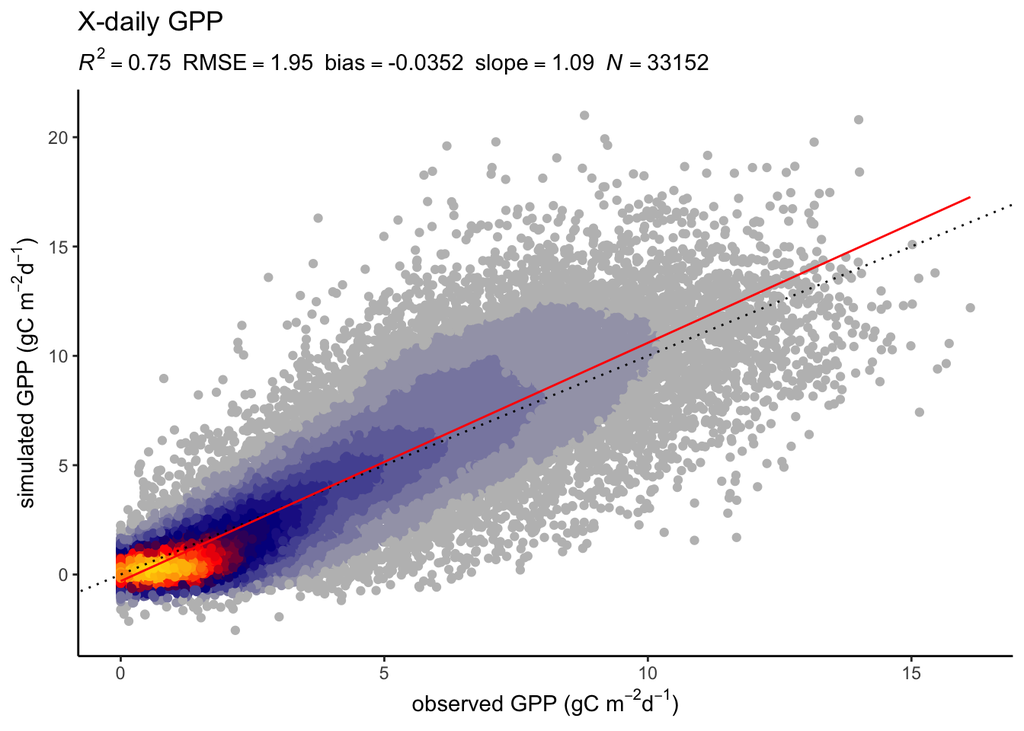

```r
out_eval$gpp$fluxnet$plot$gg_modobs_xdaily
```

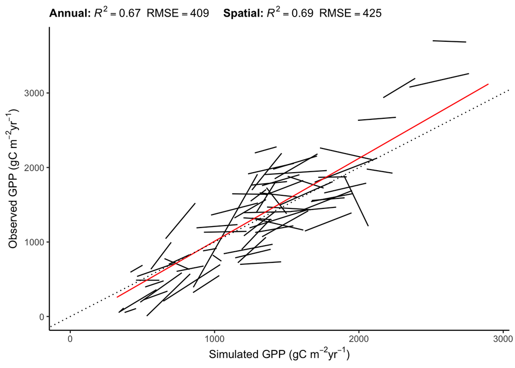

```r
out_eval$gpp$fluxnet$plot$gg_modobs_spatial_annual
```

#### Mean seasonal cycle

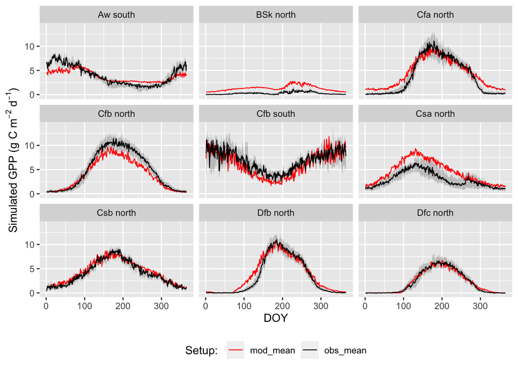

```r
## plot
out_eval$gpp$fluxnet$data$meandoydf_byclim %>%
  dplyr::filter(climatezone %in% c("Aw south", "BSk north", "Cfa north", "Cfb north", "Cfb south", "Csa north", "Csb north", "Dfb north", "Dfc north")) %>%
  dplyr::filter(koeppen_code != "-") %>%
  pivot_longer(c(obs_mean, mod_mean), names_to = "source", values_to = "gpp") %>%
  ggplot() +
  geom_ribbon(
    aes(x = doy, ymin = obs_min, ymax = obs_max),
    fill = "black",
    alpha = 0.2
    ) +
  geom_line(aes(x = doy, y = gpp, color = source), size = 0.4) +
  labs(y = expression( paste("Simulated GPP (g C m"^-2, " d"^-1, ")" ) ),
       x = "DOY") +
  facet_wrap( ~climatezone ) +    # , labeller = labeller(climatezone = list_rosetta)
  theme_gray() +
  theme(legend.position = "bottom") +
  scale_color_manual(
    name="Setup: ",
    values=c("red", "black")
    # values=c("FULL" = "#DE1A1A", "Observed" = "black")
    )
```

#### Drought response

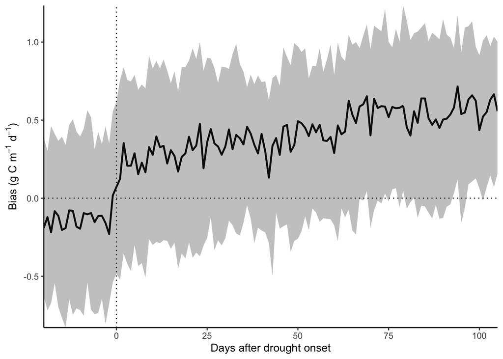

```r
source("../R/align_events.R")
source("../R/eval_droughtresponse.R")

df_dday_agg <- eval_droughtresponse(
  df = out_eval$gpp$fluxnet$data$ddf %>% rename(site = sitename),
  path_flue = "~/data/flue/flue_stocker18nphyt.csv",
  before=20,
  after=105,
  leng_threshold = 10,
  nbins=10,
  do_norm=TRUE
  )

usecol = colorRampPalette( c("wheat3", "white") )( 5 )[2]

df_dday_agg %>%
  ggplot() +
  # annotate("rect", xmin = 0, xmax = 105, ymin = -1.2, ymax = 2.2, alpha = .8, fill = usecol) +
  geom_hline(yintercept = 0, color = "black", linetype = "dotted") +
  geom_vline(xintercept = 0, color = "black", linetype = "dotted") +
  geom_line(
    aes(x = dday, y = median), size = 0.9) +
  geom_ribbon(
    aes(x = dday, ymin = q33, ymax = q66),
    alpha = 0.3) +
  scale_color_manual(values = c("BRC" = "black", "FULL" = "royalblue"), name = "Setup") +
  scale_fill_manual(values = c("BRC" = "black", "FULL" = "royalblue"), name = "Setup") +
  ylim(-1.2, 2.2) + xlim(-20, 105) +
  scale_x_continuous(expand = c(0,0)) + scale_y_continuous(expand = c(0,0)) +
  labs(x = "Days after drought onset", y = expression( paste( "Bias (g C m"^{-1}, " d"^{-1}, ")")) ) +
  theme_classic()
```

## Consistency with rpmodel

Since rsofun takes time series forcing, overwrite forcing with constant values corresponding to the arguments provided to `rpmodel::rpmodel()`.

### Setup ORG

```r
library(rpmodel)
out_pmodel <- rpmodel(
  tc             = 20,           # temperature, deg C
  vpd            = 1000,         # Pa,
  co2            = 400,          # ppm,
  fapar          = 1,            # fraction  ,
  ppfd           = 30,           # mol/m2/d,
  elv            = 0,            # m.a.s.l.,
  kphio          = 0.049977,     # quantum yield efficiency as calibrated for setup ORG by Stocker et al. 2020 GMD,
  beta           = 146,          # unit cost ratio a/b,
  c4             = FALSE,
  method_jmaxlim = "wang17",
  do_ftemp_kphio = FALSE,        # corresponding to setup ORG
  do_soilmstress = FALSE,        # corresponding to setup ORG
  verbose        = TRUE
  ) %>%
  as_tibble()
```

```r
## overwrite forcing with constant conditions (for one site)
df_drivers_rpmodel <- df_drivers_fluxnet2015 %>%
  slice(1) %>%
  mutate(forcing = purrr::map(forcing, ~mutate(.,
                                               temp = 20,
                                               vpd = 1000,
                                               ppfd = 30 / (60*60*24),
                                               patm = rpmodel::calc_patm(0),
                                               fapar = 1.0,
                                               co2 = 400,
                                               tmin = 20,
                                               tmax = 20))) %>%
  mutate(params_siml = purrr::map(params_siml, ~mutate(.,
                                                       soilmstress = FALSE,
                                                       tempstress = FALSE)))

params_modl$kphio = 0.049977
params_modl$tau_acclim_tempstress = 1.0

out_rsofun <- rsofun::runread_pmodel_f(
  df_drivers_rpmodel,
  par = params_modl
  ) %>%
  dplyr::select(data) %>%
  unnest(data) %>%
  slice(1)

## ci:ca
paste("ci:ca:", all.equal(out_pmodel$chi, out_rsofun$chi, tolerance = 1e-5))
```

```
## [1] "ci:ca: TRUE"
```

```r
## GPP
paste("GPP:", all.equal(out_pmodel$gpp, out_rsofun$gpp, tolerance = 1e-5))
```

```
## [1] "GPP: TRUE"
```

```r
## Vcmax
paste("Vcmax:", all.equal(out_pmodel$vcmax / (60*60*24), out_rsofun$vcmax, tolerance = 1e-5))
```

```
## [1] "Vcmax: TRUE"
```

```r
## Vcmax25
paste("Vcmax25:", all.equal(out_pmodel$vcmax25 / (60*60*24), out_rsofun$vcmax25, tolerance = 1e-5))
```

```
## [1] "Vcmax25: TRUE"
```

```r
## Jmax
paste("Jmax:", all.equal(out_pmodel$jmax / (60*60*24), out_rsofun$jmax, tolerance = 1e-5))
```

```
## [1] "Jmax: TRUE"
```

```r
## Jmax25
paste("Jmax25:", all.equal(out_pmodel$jmax25 / (60*60*24), out_rsofun$jmax25, tolerance = 1e-5))
```

```
## [1] "Jmax25: TRUE"
```

### Setup BRC

```r
out_pmodel <- rpmodel(
  tc             = 20,           # temperature, deg C
  vpd            = 1000,         # Pa,
  co2            = 400,          # ppm,
  fapar          = 1,            # fraction  ,
  ppfd           = 30,           # mol/m2/d,
  elv            = 0,            # m.a.s.l.,
  kphio          = 0.081785,     # quantum yield efficiency as calibrated for setup ORG by Stocker et al. 2020 GMD,
  beta           = 146,          # unit cost ratio a/b,
  c4             = FALSE,
  method_jmaxlim = "wang17",
  do_ftemp_kphio = TRUE,        # corresponding to setup ORG
  do_soilmstress = FALSE,        # corresponding to setup ORG
  verbose        = TRUE
  ) %>%
  as_tibble()
```

```r
## overwrite forcing with constant conditions (for one site)
df_drivers_rpmodel <- df_drivers_fluxnet2015 %>%
  slice(1) %>%
  mutate(forcing = purrr::map(forcing, ~mutate(.,
                                               temp = 20,
                                               vpd = 1000,
                                               ppfd = 30 / (60*60*24),
                                               patm = rpmodel::calc_patm(0),
                                               fapar = 1.0,
                                               co2 = 400,
                                               tmin = 20,
                                               tmax = 20))) %>%
  mutate(params_siml = purrr::map(params_siml, ~mutate(.,
                                                       soilmstress = FALSE,
                                                       tempstress = TRUE)))

params_modl$kphio = 0.081785
params_modl$tau_acclim_tempstress = 1.0

out_rsofun <- rsofun::runread_pmodel_f(
  df_drivers_rpmodel,
  par = params_modl
  ) %>%
  dplyr::select(data) %>%
  unnest(data) %>%
  slice(1)

## ci:ca
paste("ci:ca:", all.equal(out_pmodel$chi, out_rsofun$chi, tolerance = 1e-5))
```

```
## [1] "ci:ca: TRUE"
```

```r
## GPP
paste("GPP:", all.equal(out_pmodel$gpp, out_rsofun$gpp, tolerance = 1e-5))
```

```
## [1] "GPP: TRUE"
```

```r
## Vcmax
paste("Vcmax:", all.equal(out_pmodel$vcmax / (60*60*24), out_rsofun$vcmax, tolerance = 1e-5))
```

```
## [1] "Vcmax: TRUE"
```

```r
## Vcmax25
paste("Vcmax25:", all.equal(out_pmodel$vcmax25 / (60*60*24), out_rsofun$vcmax25, tolerance = 1e-5))
```

```
## [1] "Vcmax25: TRUE"
```

```r
## Jmax
paste("Jmax:", all.equal(out_pmodel$jmax / (60*60*24), out_rsofun$jmax, tolerance = 1e-5))
```

```
## [1] "Jmax: TRUE"
```

```r
## Jmax25
paste("Jmax25:", all.equal(out_pmodel$jmax25 / (60*60*24), out_rsofun$jmax25, tolerance = 1e-5))
```

```
## [1] "Jmax25: TRUE"
```

## Appendix

### Site list

```r
siteinfo_fluxnet2015 %>%
  dplyr::filter(sitename %in% evalsites) %>%
  kable()
```

| sitename | lon | lat | elv | year_start | year_end | classid | c4 | whc | koeppen_code | igbp_land_use | plant_functional_type |
| --- | --- | --- | --- | --- | --- | --- | --- | --- | --- | --- | --- |
| AR-SLu | -66.4598 | -33.4648 | 499.0 | 2009 | 2011 | MF | FALSE | 268.42401 | Bwk | NA | NA |
| AR-Vir | -56.1886 | -28.2395 | 97.0 | 2009 | 2012 | ENF | FALSE | 302.42755 | Csb | NA | NA |
| AT-Neu | 11.3175 | 47.1167 | 970.0 | 2002 | 2012 | GRA | FALSE | 270.08563 | Dfc | Mixed Forests | Evergreen Broadleaf Trees |
| AU-Ade | 131.1178 | -13.0769 | 81.0 | 2007 | 2009 | WSA | FALSE | 269.21866 | Aw | Savannas | Grass |
| AU-ASM | 133.2490 | -22.2830 | 606.0 | 2010 | 2013 | ENF | FALSE | 214.58427 | BSh | Open Shrublands | Shrub |
| AU-Cpr | 140.5891 | -34.0021 | 57.0 | 2010 | 2014 | SAV | FALSE | 217.31125 | BSk | Closed Shrublands | Shrub |
| AU-Cum | 150.7225 | -33.6133 | 28.0 | 2012 | 2014 | EBF | FALSE | 310.86740 | Cfa | Woody Savannas | Evergreen Broadleaf Trees |
| AU-DaP | 131.3181 | -14.0633 | 102.0 | 2007 | 2013 | GRA | FALSE | 294.63034 | Aw | Savannas | Grass |
| AU-DaS | 131.3881 | -14.1593 | 98.0 | 2008 | 2014 | SAV | FALSE | 249.25092 | Aw | Savannas | Grass |
| AU-Dry | 132.3706 | -15.2588 | 172.0 | 2008 | 2014 | SAV | FALSE | 239.15613 | Aw | Savannas | Grass |
| AU-Emr | 148.4746 | -23.8587 | 183.0 | 2011 | 2013 | GRA | FALSE | 212.93277 | Bwk | NA | NA |
| AU-Gin | 115.7138 | -31.3764 | 51.0 | 2011 | 2014 | WSA | FALSE | 194.44785 | Csa | Woody Savannas | Shrub |
| AU-GWW | 120.6541 | -30.1913 | 452.0 | 2013 | 2014 | SAV | FALSE | 183.37975 | Bwk | NA | NA |
| AU-Lox | 140.6551 | -34.4704 | 48.0 | 2008 | 2009 | DBF | FALSE | 248.41380 | Bsh | NA | NA |
| AU-RDF | 132.4776 | -14.5636 | 181.0 | 2011 | 2013 | WSA | FALSE | 290.04077 | Bwh | NA | NA |
| AU-Rig | 145.5759 | -36.6499 | 153.0 | 2011 | 2014 | GRA | FALSE | 251.43498 | Cfb | Croplands | Cereal crop |
| AU-Rob | 145.6301 | -17.1175 | 772.0 | 2014 | 2014 | EBF | FALSE | 265.16736 | Csb | NA | NA |
| AU-Stp | 133.3502 | -17.1507 | 227.0 | 2008 | 2014 | GRA | FALSE | 283.41589 | BSh | Grasslands | Grass |
| AU-TTE | 133.6400 | -22.2870 | 552.0 | 2012 | 2013 | OSH | FALSE | 217.10576 | BWh | Open Shrublands | Shrub |
| AU-Tum | 148.1517 | -35.6566 | 932.0 | 2001 | 2014 | EBF | FALSE | 248.48276 | Cfb | Evergreen Broadleaf Forest | Evergreen Broadleaf Trees |
| AU-Wac | 145.1878 | -37.4259 | 562.0 | 2005 | 2008 | EBF | FALSE | 163.75224 | Cfb | Evergreen Broadleaf Forest | Evergreen Broadleaf Trees |
| AU-Whr | 145.0294 | -36.6732 | 152.0 | 2011 | 2014 | EBF | FALSE | 271.49738 | Cfb | Woody Savannas | Shrub |
| AU-Wom | 144.0944 | -37.4222 | 705.0 | 2010 | 2012 | EBF | FALSE | 189.57100 | Cfb | Evergreen Broadleaf Forest | Evergreen Broadleaf Trees |
| AU-Ync | 146.2907 | -34.9893 | 125.0 | 2012 | 2014 | GRA | FALSE | 199.15875 | BSk | Croplands | Cereal crop |
| BE-Bra | 4.5206 | 51.3092 | 16.0 | 1996 | 2014 | MF | FALSE | 85.68380 | Cfb | Mixed Forests | Deciduous Broadleaf Trees |
| BE-Vie | 5.9981 | 50.3051 | 493.0 | 1996 | 2014 | MF | FALSE | 312.76520 | Cfb | Mixed Forests | Deciduous Broadleaf Trees |
| BR-Sa3 | -54.9714 | -3.0180 | 100.0 | 2000 | 2004 | EBF | FALSE | 207.06451 | Am | Evergreen Broadleaf Forest | Evergreen Broadleaf Trees |
| CA-Man | -98.4808 | 55.8796 | 259.0 | 1994 | 2008 | ENF | FALSE | 52.67784 | Dfc | Evergreen Needleleaf Forest | Evergreen Needleleaf Trees |
| CA-NS1 | -98.4839 | 55.8792 | 260.0 | 2001 | 2005 | ENF | FALSE | 50.25988 | Dfc | Evergreen Needleleaf Forest | Evergreen Needleleaf Trees |
| CA-NS2 | -98.5247 | 55.9058 | 260.0 | 2001 | 2005 | ENF | FALSE | 59.02733 | Dfc | Evergreen Needleleaf Forest | Evergreen Needleleaf Trees |

[output cut: 99 more lines]